# Figure 2 | Source data and plotting code

This report accompanies Figure 2 on LSOPC intervention in the mouse model. Panels B and G are redrawn from the values used for the GraphPad Prism plots. Bars show mean ± SD, with individual observations overlaid. The report also displays the immunoblot quantification for F, the exported PCoA coordinates for H, and the exported LEfSe results for I. Keep the five Excel workbooks in the same folder as this Rmd and click **Knit** in RStudio.

```r
library(readxl)
# Shared utilities: this Rmd is knitted from Figure 2/.
source("../scripts/plot_functions.R")

groups <- c("Control", "AGEs", "L-LSOPC", "H-LSOPC")
group_colors <- lsopc_group_colors[groups]

source_path <- function(panel) {
  path <- paste0("Figure 2", panel, ".xlsx")
  if (!file.exists(path)) stop("Missing workbook: ", path, call. = FALSE)
  path
}

read_block <- function(panel, range, types) {
  read_excel(source_path(panel), range = range, col_types = types,
             col_names = FALSE, .name_repair = function(x) paste0("V", seq_along(x)))
}

plot_grouped <- function(values, labels, ylab) {
  # Each matrix has observations in rows and treatment groups in columns.
  means <- vapply(values, colMeans, numeric(length(groups)))
  sds <- vapply(values, function(x) apply(x, 2, sd), numeric(length(groups)))
  positions <- barplot(means, beside = TRUE, names.arg = labels,
                       col = group_colors, border = NA, ylab = ylab,
                       ylim = c(0, 1.25 * max(means + sds, unlist(values))))
  arrows(positions, means - sds, positions, means + sds,
         code = 3, angle = 90, length = 0.04)
  for (item in seq_along(values)) {
    observations <- values[[item]]
    offsets <- seq(-0.22, 0.22, length.out = nrow(observations))
    for (group in seq_along(groups)) {
      points(positions[group, item] + offsets, observations[, group],
             pch = 21, bg = "white", cex = 0.65)
    }
  }
  legend("topright", groups, fill = group_colors, border = NA,
         bty = "n", horiz = TRUE, cex = 0.8)
}

unpack_rows <- function(block, n) {
  lapply(seq_len(nrow(block)), function(i) {
    matrix(as.numeric(unlist(block[i, -1], use.names = FALSE)),
           nrow = n, ncol = length(groups))
  })
}
```

## Data, units, and statistical interpretation

The treatment-group palette is defined in `../scripts/plot_functions.R` and reused here. The workbook observations are summarized as **mean ± SD**; error bars and overlaid points are descriptive. This report does **not** independently perform normality testing, variance-homogeneity testing, one-way ANOVA, Tukey post hoc comparisons, or multiple-testing correction. Such results should be reported only when supported by the original statistical analysis and the manuscript Methods.

| Panel | Displayed measurement | Observations in exported workbook | Analysis scope here |
| --- | --- | --- | --- |
| 2B | Organ index (mg/g) | 8 per group per organ | Mean ± SD; no inferential test rerun |
| 2F | Immunoblot quantification (relative units as exported) | 3 per group per protein | Mean ± SD table |
| 2G | Relative mRNA expression (dimensionless) | 3 per group per target | Mean ± SD; no inferential test rerun |
| 2H | Unweighted UniFrac PCoA scores (dimensionless); axis variance (%) | 5 per group | Exported coordinates plotted; no ordination recalculation |
| 2I | LEfSe LDA score, *p* and adjusted *p* values as exported | Exported taxa table | Tabulation only; LEfSe not rerun |

The `n` above denotes the number of observations in the exported workbooks.

## Figure 2B | Organ indices

Figure 2B.xlsx. Each organ has eight measurements per group. The workbook label “Spieen” is displayed as “Spleen”.

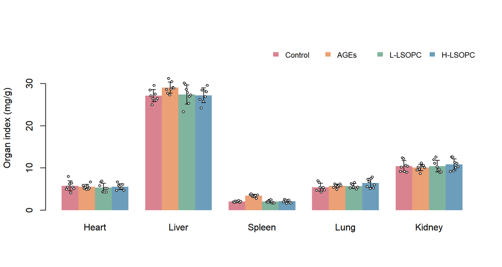

```r
organ <- read_block("B", "A3:AG7", c("text", rep("numeric", 32)))
organ_names <- sub("^Spieen$", "Spleen", organ[[1]])
plot_grouped(unpack_rows(organ, 8), organ_names, "Organ index (mg/g)")
```

## Figure 2F | Immunoblot quantification

Figure 2F.xlsx contains three immunoblot quantification values per group for each of five proteins. The table below summarizes these values.

```r
blot <- read_block("F", "A3:M7", c("text", rep("numeric", 12)))
blot_values <- unpack_rows(blot, 3)
blot_summary <- t(vapply(blot_values, function(x) {
  sprintf("%.3f ± %.3f", colMeans(x), apply(x, 2, sd))
}, character(length(groups))))
colnames(blot_summary) <- groups
knitr::kable(data.frame(Protein = blot[[1]], blot_summary, check.names = FALSE),
             caption = "Immunoblot quantification (mean ± SD)")
```

Immunoblot quantification (mean ± SD)

| Protein | Control | AGEs | L-LSOPC | H-LSOPC |
| --- | --- | --- | --- | --- |
| RAGE | 0.117 ± 0.052 | 0.758 ± 0.072 | 0.460 ± 0.055 | 0.265 ± 0.063 |
| p38 MAPK | 1.011 ± 0.156 | 0.997 ± 0.173 | 1.009 ± 0.178 | 1.036 ± 0.155 |
| P-p38 MAPK | 0.130 ± 0.129 | 0.795 ± 0.091 | 0.427 ± 0.192 | 0.286 ± 0.172 |
| NF-κB p65 | 0.716 ± 0.121 | 0.755 ± 0.118 | 0.725 ± 0.106 | 0.705 ± 0.136 |
| P-NFκB p65 | 0.040 ± 0.015 | 0.605 ± 0.070 | 0.264 ± 0.051 | 0.161 ± 0.030 |

## Figure 2G | Relative mRNA expression

Figure 2G.xlsx contains relative expression values for three targets, with three observations per group per target.

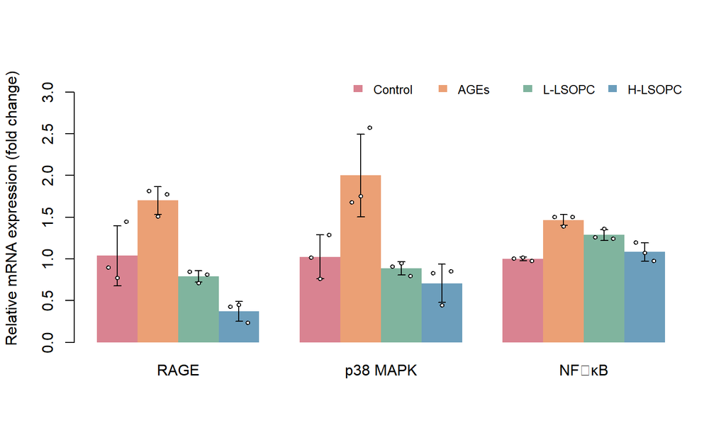

```r
qpcr <- read_block("G", "A3:E11", c("text", rep("numeric", 4)))
target_start <- seq(1, nrow(qpcr), by = 3)
qpcr_values <- lapply(target_start, function(i) {
  as.matrix(qpcr[i + 0:2, 2:5])
})
plot_grouped(qpcr_values, qpcr[[1]][target_start], "Relative mRNA expression (fold change)")
```

## Figure 2H | Unweighted UniFrac PCoA

Figure 2H.xlsx contains exported PCoA coordinates for five samples per group and the variance explained by each axis. The scatter plot uses the exported scores directly (dimensionless ordination coordinates). Group assignment is read from the sample ID prefix.

The original platform export shows the group ellipses. The R redraw below uses the Excel coordinates for the sample points and the axis percentages. The ordination and ellipse parameters are not recalculated in this report.

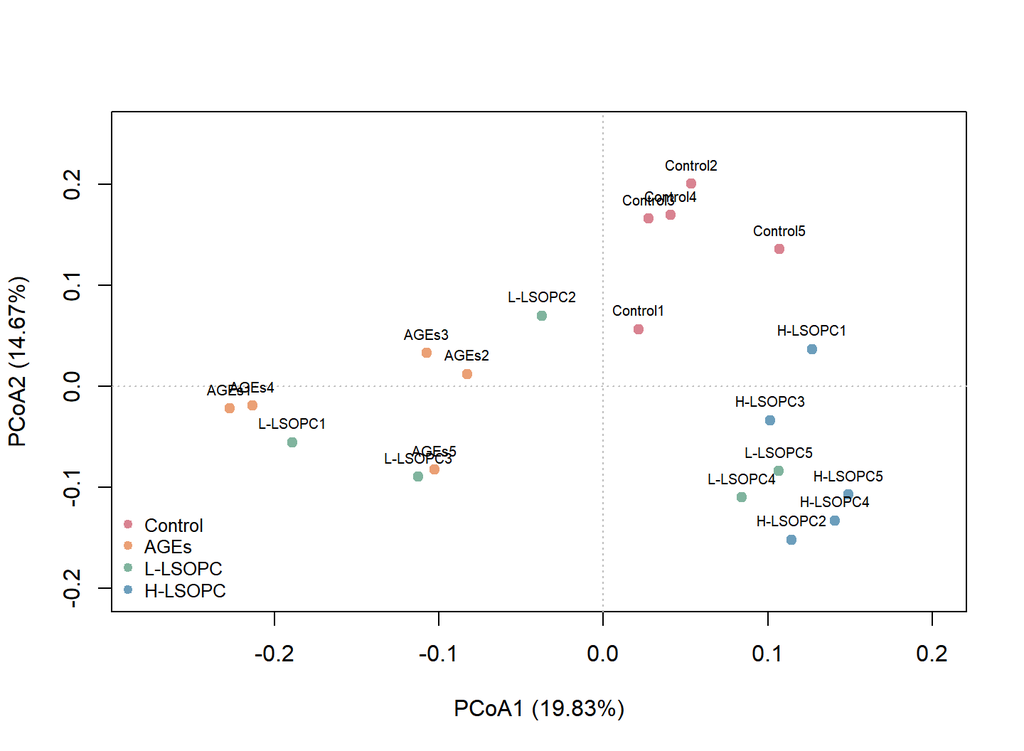

```r
scores <- read_block("H", "A3:C22", c("text", "numeric", "numeric"))
variance <- read_block("H", "A26:B27", c("text", "numeric"))
sample_ids <- scores[[1]]
sample_groups <- sub("[0-9]+$", "", sample_ids)
stopifnot(all(sample_groups %in% groups))
axis_labels <- sprintf("%s (%.2f%%)", variance[[1]], 100 * variance[[2]])

plot(scores[[2]], scores[[3]], pch = 19, col = group_colors[sample_groups],
     xlab = axis_labels[1], ylab = axis_labels[2],
     xlim = extendrange(scores[[2]], f = 0.14),
     ylim = extendrange(scores[[3]], f = 0.15))
abline(h = 0, v = 0, lty = 3, col = "grey75")
text(scores[[2]], scores[[3]], labels = sample_ids, pos = 3, cex = 0.62)
legend("bottomleft", groups, col = group_colors, pch = 19, bty = "n", cex = 0.8)
```

## Figure 2I | LEfSe results

Figure 2I.xlsx contains the exported LEfSe results at the phylum, class, order, family, and genus levels. The analysis report specifies an LDA score cutoff of 2. The tables below give the taxonomy, group code, LDA score, P value, and adjusted P value for each reported taxon. Group codes A–D should be checked against the original cladogram legend before assigning treatment names.

The cladogram, when the original PNG is supplied, is the original analysis output. The workbook documents the highlighted taxa and their scores. Re-running LEfSe requires the original abundance data and sample group assignments.

```r
lefse_path <- source_path("I")
for (sheet in excel_sheets(lefse_path)) {
  if (!endsWith(sheet, ".LDA")) next
  cat("\n\n### ", sub("\\.LDA$", "", sheet), "\n\n", sep = "")
  results <- read_excel(lefse_path, sheet = sheet)
  print(knitr::kable(results, digits = 5))
  cat("\n\n")
}
```

### Class

| Taxonomy | Group | LDA | Pvalue | padj |
| --- | --- | --- | --- | --- |
| c__Deferribacteres | A | 2.57991 | 0.00212 | 0.00212 |
| c__Gammaproteobacteria | D | 4.22541 | 0.02975 | 0.02975 |

### Family

| Taxonomy | Group | LDA | Pvalue | padj |
| --- | --- | --- | --- | --- |
| f__Mycoplasmataceae | A | 3.06529 | 0.02376 | 0.02376 |
| f__Deferribacteraceae | A | 2.57994 | 0.00212 | 0.00212 |
| f__Mitochondria | A | 2.21034 | 0.02317 | 0.02317 |
| f__Marinifilaceae | C | 3.87204 | 0.04956 | 0.04956 |
| f__Ruminococcaceae | D | 4.47522 | 0.03037 | 0.03037 |
| f__Sutterellaceae | D | 4.21785 | 0.02960 | 0.02960 |
| f__Clostridiaceae | D | 3.18880 | 0.02656 | 0.02656 |

### Genus

| Taxonomy | Group | LDA | Pvalue | padj |
| --- | --- | --- | --- | --- |
| g__Muribaculum | A | 4.14790 | 0.04120 | 0.04120 |
| g__Ureaplasma | A | 3.06301 | 0.02021 | 0.02021 |
| g__Candidatus_Stoquefichus | A | 2.63005 | 0.04111 | 0.04111 |
| g__Mucispirillum | A | 2.57999 | 0.00212 | 0.00212 |
| g__Mitochondria | A | 2.22152 | 0.02317 | 0.02317 |
| g__[Eubacterium]_siraeum_group | B | 2.88436 | 0.02836 | 0.02836 |
| g__Odoribacter | C | 3.89363 | 0.01395 | 0.01395 |
| g__[Eubacterium]_xylanophilum_group | C | 3.37838 | 0.01917 | 0.01917 |
| g__Tyzzerella | C | 2.70084 | 0.02439 | 0.02439 |
| g__Ruminococcaceae_uncultured | D | 4.50141 | 0.00501 | 0.00501 |
| g__Parasutterella | D | 4.21785 | 0.02960 | 0.02960 |
| g__Prevotellaceae_NK3B31_group | D | 3.63412 | 0.00542 | 0.00542 |
| g__Clostridium_sensu_stricto_1 | D | 3.18927 | 0.02193 | 0.02193 |
| g__Family_XIII_AD3011_group | D | 2.66976 | 0.01249 | 0.01249 |
| g__Gordonibacter | D | 2.66140 | 0.01312 | 0.01312 |
| g__Mycoplasma | D | 2.44955 | 0.04646 | 0.04646 |

### Order

| Taxonomy | Group | LDA | Pvalue | padj |
| --- | --- | --- | --- | --- |
| o__Mycoplasmatales | A | 3.06522 | 0.02376 | 0.02376 |
| o__Deferribacterales | A | 2.57990 | 0.00212 | 0.00212 |
| o__Rickettsiales | A | 2.21133 | 0.02317 | 0.02317 |
| o__Burkholderiales | D | 4.21556 | 0.02960 | 0.02960 |
| o__Clostridiales | D | 3.18880 | 0.02656 | 0.02656 |

### Phylum

| Taxonomy | Group | LDA | Pvalue | padj |
| --- | --- | --- | --- | --- |
| p__Deferribacterota | A | 2.57988 | 0.00212 | 0.00212 |
| p__Proteobacteria | D | 4.22684 | 0.02975 | 0.02975 |